# Étape 2 – Analyse exploratoire des données TfL

Équipe 15

2025-11-24

## 1. Introduction

Cette étape vise à explorer visuellement les données de comptage cycliste afin d’identifier des patterns temporels et contextuels. Les visualisations respectent explicitement les principes vus dans les modules récents du cours :

- Mauvaises représentations : axes honnêtes, graphiques non trompeurs
- Biais algorithmique : pas d’interprétation causale, seulement descriptive
- Confidentialité : données agrégées, aucun identifiant individuel
- Interprétation des modèles : préparation à l’utilisation future d’un modèle de Poisson

# 2. Chargement des données nettoyées

On charge le fichier traité à l’Étape 1 (data/tfl_clean.rds).

```r
data <- readr::read_rds("data/tfl_clean.rds")
glimpse(data)
```

```
## Rows: 870,144
## Columns: 11
## $ wave      <chr> "2024 W1 spring", "2024 W1 spring", "2024 W1 spring", "2024 …
## $ site_id   <chr> "ML0210", "ML0210", "ML0210", "ML0210", "ML0210", "ML0210", …
## $ date      <chr> "09/07/2024", "09/07/2024", "09/07/2024", "09/07/2024", "09/…
## $ weather   <chr> "dry", "dry", "dry", "dry", "dry", "dry", "dry", "dry", "dry…
## $ time      <fct> 06:00:00, 06:15:00, 06:30:00, 06:45:00, 07:00:00, 07:15:00, …
## $ day       <fct> Weekday, Weekday, Weekday, Weekday, Weekday, Weekday, Weekda…
## $ round     <chr> "A", "A", "A", "A", "A", "A", "A", "A", "A", "A", "A", "A", …
## $ direction <chr> "northbound", "northbound", "northbound", "northbound", "nor…
## $ path      <chr> "Carriageway", "Carriageway", "Carriageway", "Carriageway", …
## $ mode      <chr> "cargo bikes", "cargo bikes", "cargo bikes", "cargo bikes", …
## $ count     <int> 0, 0, 0, 0, 0, 0, 0, 0, 0, 0, 0, 0, 0, 0, 0, 0, 0, 0, 0, 0, …
```

# 3. Statistiques descriptives de base

```r
summary(data$count)
```

```
##    Min. 1st Qu.  Median    Mean 3rd Qu.    Max.
##   0.000   0.000   0.000   3.476   1.000 498.000
```

```r
data |>
summarise(
moyenne = mean(count),
mediane = median(count),
ecart_type = sd(count),
min = min(count),
max = max(count)
)
```

```
## # A tibble: 1 × 5
##   moyenne mediane ecart_type   min   max
##     <dbl>   <dbl>      <dbl> <int> <int>
## 1    3.48       0       12.6     0   498
```

# 4. Graphique 1 – Distribution du nombre de cyclistes

Histogramme descriptif respectant les règles visuelles du cours (axe des x débutant à 0, pas de manipulation d’échelle).

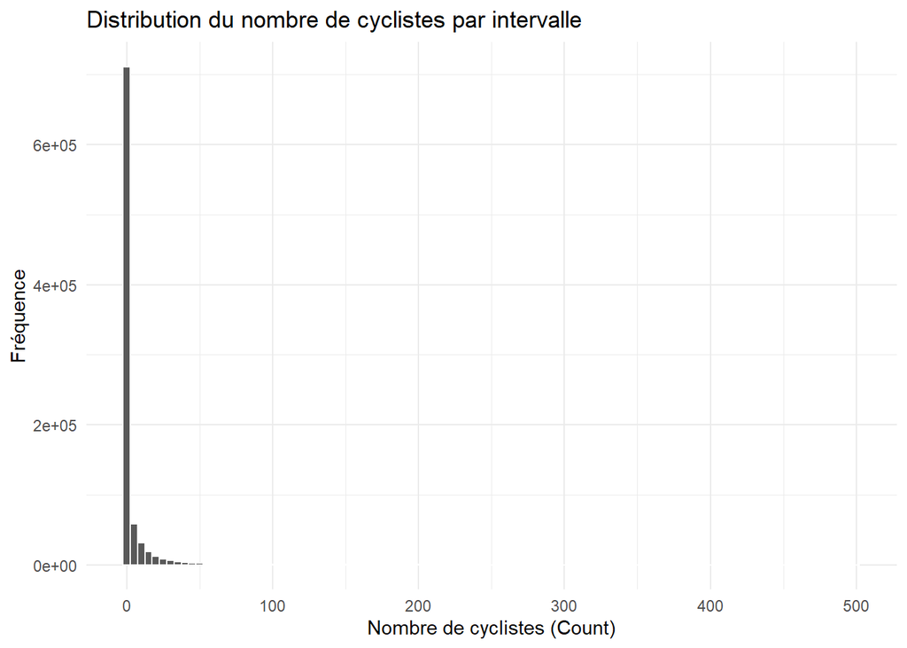

```r
ggplot(data, aes(x = count)) +
geom_histogram(binwidth = 5, color = "white") +
labs(
title = "Distribution du nombre de cyclistes par intervalle",
x = "Nombre de cyclistes (Count)",
y = "Fréquence"
) +
theme_minimal()
```

# 5. Graphique 2 – Count moyen selon la météo

Comparaison descriptive entre conditions dry et wet (toujours sans causalité, comme rappelé dans le cours).

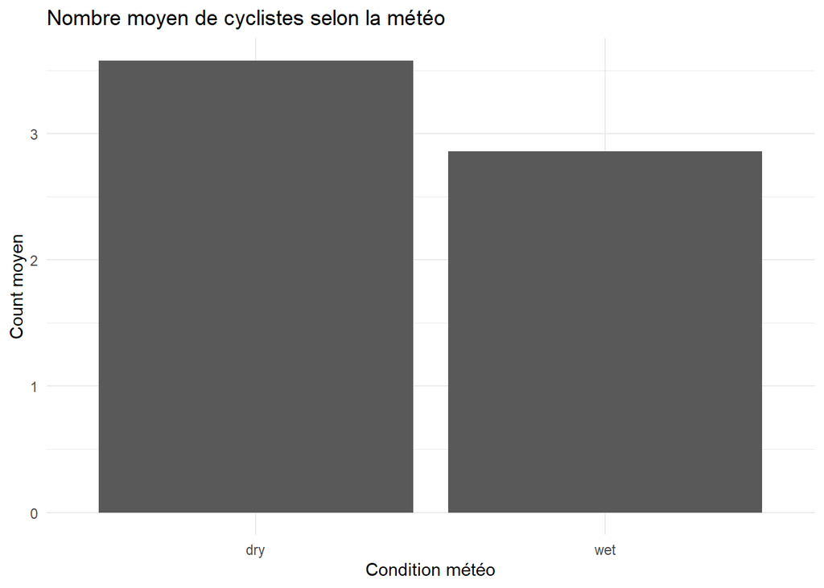

```r
data |>
mutate(weather = factor(weather, levels = c("dry", "wet"))) |>
group_by(weather) |>
summarise(moyenne = mean(count)) |>
ggplot(aes(x = weather, y = moyenne)) +
geom_col() +
labs(
title = "Nombre moyen de cyclistes selon la météo",
x = "Condition météo",
y = "Count moyen"
) +
theme_minimal()
```

# 6. Graphique 3 – Count moyen selon l’heure de la journée

Analyse des patterns temporels : pics matin/soir et creux de journée, utiles pour le futur modèle.

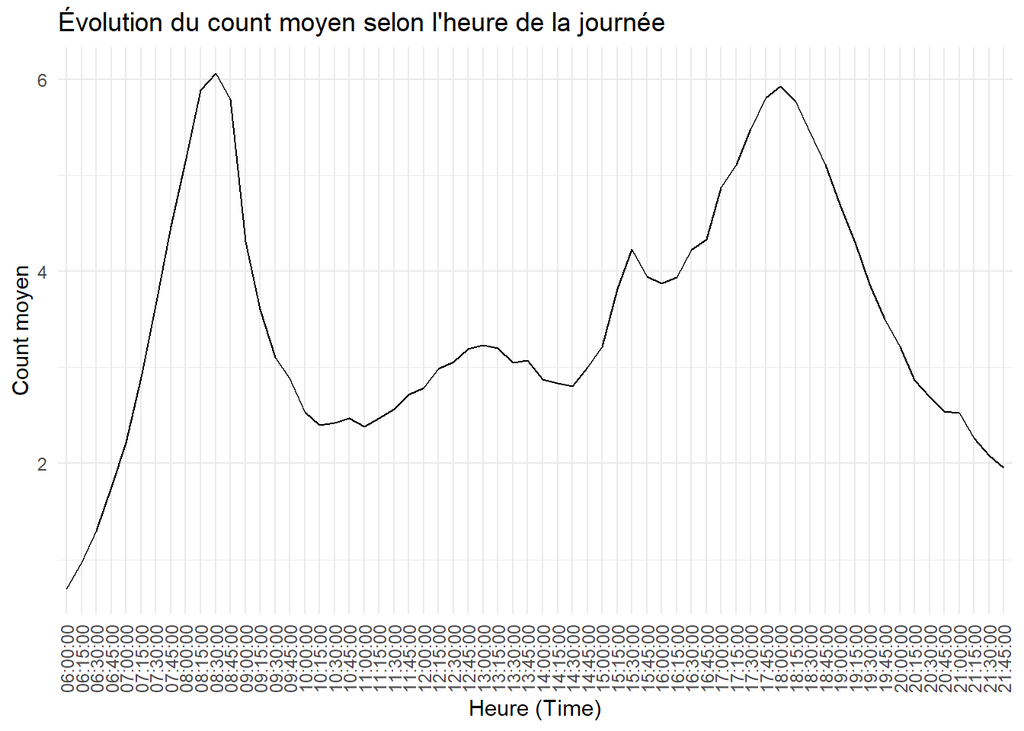

```r
data |>
group_by(time) |>
summarise(moyenne = mean(count)) |>
ggplot(aes(x = time, y = moyenne, group = 1)) +
geom_line() +
labs(
title = "Évolution du count moyen selon l'heure de la journée",
x = "Heure (Time)",
y = "Count moyen"
) +
theme_minimal() +
theme(axis.text.x = element_text(angle = 90, vjust = 0.5))
```

## 7. Commentaires exploratoires

La distribution de count est très asymétrique : beaucoup d’intervalles présentent zéro cycliste, et quelques périodes montrent des volumes élevés.

On observe un count moyen plus élevé en condition dry qu’en condition wet : effet descriptif seulement, sans inférence.

Le pattern horaire montre clairement des pics en début et fin de journée (heures de travail), ce qui guidera l’Étape 3 (modèle de Poisson).

Aucune donnée personnelle n’est présente : seulement des comptages agrégés.

Les figures sont construites selon les principes du cours : axes honnêtes, représentation fidèle, absence de causalité forcée.